# Figure 02 Short Chain Fatty Acids

```r
knitr::opts_chunk$set(
  warning = FALSE,
  error = TRUE,
  echo = TRUE,
  fig.width = 10,
  fig.height = 7)
```

```r
library("magrittr")
library("data.table")
library("ggplot2"); packageVersion("ggplot2")
```

```
## [1] '3.3.5'
```

```r
library("patchwork"); packageVersion("patchwork")
```

```
## [1] '1.1.1'
```

```r
library("GGally"); packageVersion("GGally")
```

```
## [1] '2.1.2'
```

```r
library("ggcorrplot"); packageVersion("ggcorrplot")
```

```
## [1] '0.1.3'
```

```r
library("ggbeeswarm"); packageVersion("ggbeeswarm")
```

```
## [1] '0.6.0'
```

```r
theme_set(theme_bw())
scaleColorManualTreatment <-
  scale_color_manual(
    values =
      c(
        placebo = "gray50",
        wbf10 = "darkblue",
        wbf11 = "darkgreen"
      )
  )
scaleFillManualTreatment <-
  scale_fill_manual(
    values =
      c(
        placebo = "gray50",
        wbf10 = "darkblue",
        wbf11 = "darkgreen"
      )
  )
studyArmPretty <-
  c(placebo = "Placebo",
    wbf10 = "WBF-010",
    wbf11 = "WBF-011")
scaleColorTreatmentManPretty <-
  scale_color_manual(
    values =
      c(
        "Placebo" = "gray50",
        "WBF-010" = "darkblue",
        "WBF-011" = "darkgreen"
      )
  )
scaleFillTreatmentManPretty <-
  scale_fill_manual(
    values =
      c(
        "Placebo" = "gray50",
        "WBF-010" = "darkblue",
        "WBF-011" = "darkgreen"
      )
  )
scfaNamePretty <-
  c("Acetic acid" = "Acetate",
    "Propionic acid" = "Propionate",
    "Butyric acid" = "Butyrate")
vecOrderScfa <-
  c("Acetic acid", "Propionic acid", "Butyric acid") %>%
  rev()
```

# Load data

```r
tabMetabolonScfaLong <- readRDS(params$tabMetabolonScfaLong)
tabScfaEventWide <- readRDS(params$tabScfaEventWide)
tabSfu <- readRDS(params$tabSfu)
tabFecalScfa <- readRDS(params$tabFecalScfa)
# Per protocol
tabPp <- readRDS(params$tabPp)
```

Show participants per arm represented in main specimen collection.

```r
tabMetabolonScfaLong %>%
  .[, .(No.Participants = uniqueN(Subject)), by = "treatment"] %>%
  knitr::kable(digits = 3)
```

| treatment | No.Participants |
| --- | --- |
| placebo | 14 |
| wbf11 | 19 |
| wbf10 | 18 |

# Fig 1A: Delta SCFA

## Prepare table

```r
tabKey <- NULL
tabKey <-
  tabMetabolonScfaLong %>% copy %>%
  .[c("Acetic acid", "Propionic acid", "Butyric acid"), on = "BIOCHEMICAL"] %>%
  # Set observations from the same subject+time to the mean among replicates
  # There are not many of these...
  .[, ConcMicroMolePerLiter := mean(ConcMicroMolePerLiter),
    by = .(BIOCHEMICAL, Subject, Event)] %>%
  .[, .SD[1], by = .(BIOCHEMICAL, Subject, Event)]
tabKey %>% nrow()
```

```
## [1] 306
```

```r
tabKey %>% .$BIOCHEMICAL %>% unique()
```

```
## [1] "Acetic acid"    "Propionic acid" "Butyric acid"
```

```r
# Define subject factor order based on butyrate concentration at baseline
orderSubjectBaselineButyrate <-
  tabKey %>% copy %>%
  .[(BIOCHEMICAL == "Butyric acid")] %>%
  .[(Event == "Baseline")] %>%
  setorder(treatment, ConcMicroMolePerLiter) %>%
  .$Subject
tabKey[, subjectFactor := factor(x = Subject, levels = orderSubjectBaselineButyrate)]
```

## SCFA at baseline

```r
tabKeyScfaBaseline <-
  tabKey %>% copy %>%
  .[(Event == "Baseline")] %>%
  .[, Treatment := studyArmPretty[treatment]]
# Compute the medians
tabKeyScfaBaseline %>%
      .[, .(
        GrandMedian = median(ConcMicroMolePerLiter, na.rm = TRUE),
        stdDev = sd(ConcMicroMolePerLiter, na.rm = TRUE)
      ), by = "BIOCHEMICAL"] %>%
  knitr::kable(digits = 1)
```

| BIOCHEMICAL | GrandMedian | stdDev |
| --- | --- | --- |
| Acetic acid | 60.2 | 41.6 |
| Propionic acid | 1.6 | 1.0 |
| Butyric acid | 0.5 | 0.3 |

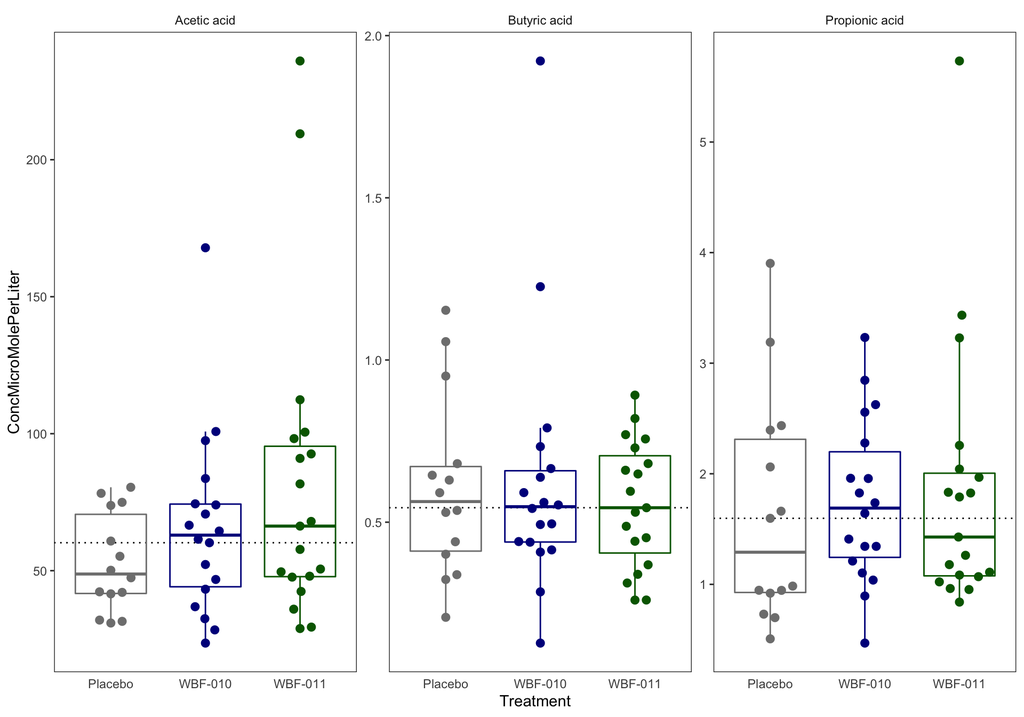

```r
tabKeyScfaBaseline %>%
  ggplot(aes(Treatment, ConcMicroMolePerLiter, color = Treatment)) +
  facet_wrap(~BIOCHEMICAL, scales = "free_y") +
  geom_hline(
    linetype = 3,
    data = tabKeyScfaBaseline %>%
      .[, .(GrandMedian = median(ConcMicroMolePerLiter, na.rm = TRUE)),
        by = "BIOCHEMICAL"],
    mapping = aes(yintercept = GrandMedian),
    show.legend = FALSE) +
  geom_boxplot(
    fill = NA,
    outlier.shape = NA
  ) +
  geom_point(
    size = 3,
    stroke = 0,
    position = position_beeswarm(cex = 4, groupOnX = TRUE)
  ) +
  scaleColorTreatmentManPretty +
  theme(
    panel.grid = element_blank(),
    axis.ticks.x = element_blank(),
    strip.background = element_blank(),
    legend.position = "none",
    )
```

## $\Delta$ Butyrate Concentration

```r
tabScfaDeltas <- tabWinGrpDelta <- tabBwGrpDelta <- NULL
tabScfaDeltas <-
  tabKey %>%
  # unfortunate case-complexity
  .[, Treatment := copy(treatment)] %>%
  # Compute concentration deltas
  dcast.data.table(
    formula = Treatment + Subject + BIOCHEMICAL ~ Event,
    value.var = "ConcMicroMolePerLiter",
    fun.aggregate = mean,
    na.rm = TRUE) %>%
  .[, deltaConcentration := Week12 - Baseline]

# Within-group, research question: Did it increase?
tabWinGrpDeltaGreater <-
  tabScfaDeltas %>%
  .[, .(
    wilcoxOut = list(
      wilcox.test(
        x = deltaConcentration,
        alternative = "greater",
        conf.int = TRUE,
        mu = 0.0,
        paired = FALSE)
    )
  ),
  by = .(Treatment, BIOCHEMICAL)]

# Collect the full confidence interval for plotting
tabWinGrpDelta <-
  tabScfaDeltas %>%
  .[, .(
    wilcoxOut = list(
      wilcox.test(
        x = deltaConcentration,
        alternative = "two.sided",
        conf.int = TRUE,
        mu = 0.0,
        paired = FALSE)
    )
  ),
  by = .(Treatment, BIOCHEMICAL)]
# Extract key results from test
extract_wi = function(wilcoxOut){data.table(
  pvalue = wilcoxOut$p.value,
  statistic = wilcoxOut$statistic,
  estimate = wilcoxOut$estimate,
  confIntLo = wilcoxOut$conf.int[1],
  confIntHi = wilcoxOut$conf.int[2]
)}
tabWinGrpDelta <- tabWinGrpDelta[, extract_wi(wilcoxOut[[1]]),
                                 by = .(Treatment, BIOCHEMICAL)]
tabWinGrpDeltaGreater <-
  tabWinGrpDeltaGreater[, extract_wi(wilcoxOut[[1]]),
                        by = .(Treatment, BIOCHEMICAL)]
setorder(tabWinGrpDelta, Treatment, -pvalue)
setorder(tabWinGrpDeltaGreater, Treatment, -pvalue)
# show table
tabWinGrpDelta %>% knitr::kable(digits = 3)
```

| Treatment | BIOCHEMICAL | pvalue | statistic | estimate | confIntLo | confIntHi |
| --- | --- | --- | --- | --- | --- | --- |
| placebo | Butyric acid | 1.000 | 52 | 0.000 | -0.089 | 0.098 |
| placebo | Acetic acid | 0.670 | 45 | -3.999 | -14.411 | 11.849 |
| placebo | Propionic acid | 0.020 | 16 | -0.346 | -0.618 | -0.112 |
| wbf10 | Butyric acid | 0.523 | 70 | -0.050 | -0.247 | 0.112 |
| wbf10 | Acetic acid | 0.325 | 62 | -5.604 | -18.266 | 7.280 |
| wbf10 | Propionic acid | 0.154 | 52 | -0.296 | -0.899 | 0.159 |
| wbf11 | Propionic acid | 0.738 | 104 | 0.081 | -0.491 | 0.505 |
| wbf11 | Acetic acid | 0.515 | 78 | -7.684 | -33.044 | 13.426 |
| wbf11 | Butyric acid | 0.014 | 155 | 0.147 | 0.025 | 0.297 |

```r
tabWinGrpDeltaGreater %>% knitr::kable(digits = 3)
```

| Treatment | BIOCHEMICAL | pvalue | statistic | estimate | confIntLo | confIntHi |
| --- | --- | --- | --- | --- | --- | --- |
| placebo | Propionic acid | 0.992 | 16 | -0.346 | -0.543 | Inf |
| placebo | Acetic acid | 0.687 | 45 | -3.999 | -11.740 | Inf |
| placebo | Butyric acid | 0.524 | 52 | 0.000 | -0.079 | Inf |
| wbf10 | Propionic acid | 0.929 | 52 | -0.296 | -0.763 | Inf |
| wbf10 | Acetic acid | 0.848 | 62 | -5.604 | -15.753 | Inf |
| wbf10 | Butyric acid | 0.752 | 70 | -0.050 | -0.215 | Inf |
| wbf11 | Acetic acid | 0.755 | 78 | -7.684 | -28.107 | Inf |
| wbf11 | Propionic acid | 0.369 | 104 | 0.081 | -0.383 | Inf |
| wbf11 | Butyric acid | 0.007 | 155 | 0.147 | 0.049 | Inf |

```r
# What percent increase is this for butyrate?
medianButBaseline <-
  tabKey[(BIOCHEMICAL == "Butyric acid" &
            Treatment == "wbf11" &
            Event == "Baseline"),
         median(ConcMicroMolePerLiter)]
# This is the percent increase from the median baseline concentration:
(
  (medianButBaseline +
     tabWinGrpDelta[(BIOCHEMICAL == "Butyric acid" & Treatment == "wbf11")]$estimate) /
    medianButBaseline - 1) %>%
  multiply_by(100) %>%
  round(digits = 0)
```

```
## [1] 27
```

```r
# Between-group test on deltas
tabBwGrpDelta <-
  tabScfaDeltas %>%
  .[(Treatment %in% c("wbf11", "placebo"))] %>%
  .[, .(
    wilcoxOut = list(
      try(expr = {
        wilcox.test(
          x = deltaConcentration[(Treatment == "wbf11")],
          y = deltaConcentration[(Treatment == "placebo")],
          alternative = "greater",
          conf.int = TRUE,
          paired = FALSE)
      }, silent = TRUE)
    )
  ),
  by = .(BIOCHEMICAL)]
# Extract key results from test
extract_wi = function(wilcoxOut){
  data.table(
    pvalue = wilcoxOut$p.value,
    statistic = wilcoxOut$statistic,
    estimate = wilcoxOut$estimate,
    confIntLo = wilcoxOut$conf.int[1],
    confIntHi = wilcoxOut$conf.int[2]
  )
}
# Check that test didn't fail and return non-sense (missing or funky data)
tabBwGrpDelta[, success := inherits(wilcoxOut[[1]], "htest"),
              by = .(BIOCHEMICAL)]
tabBwGrpDelta <-
  tabBwGrpDelta %>%
  .[(success), try({extract_wi(wilcoxOut[[1]])}, silent = TRUE),
    by = .(BIOCHEMICAL)]
setorder(tabBwGrpDelta, -pvalue)
tabBwGrpDelta %>% knitr::kable(digits = 3)
```

| BIOCHEMICAL | pvalue | statistic | estimate | confIntLo | confIntHi |
| --- | --- | --- | --- | --- | --- |
| Acetic acid | 0.634 | 124 | -6.630 | -27.814 | Inf |
| Propionic acid | 0.057 | 177 | 0.399 | -0.033 | Inf |
| Butyric acid | 0.042 | 181 | 0.133 | 0.009 | Inf |

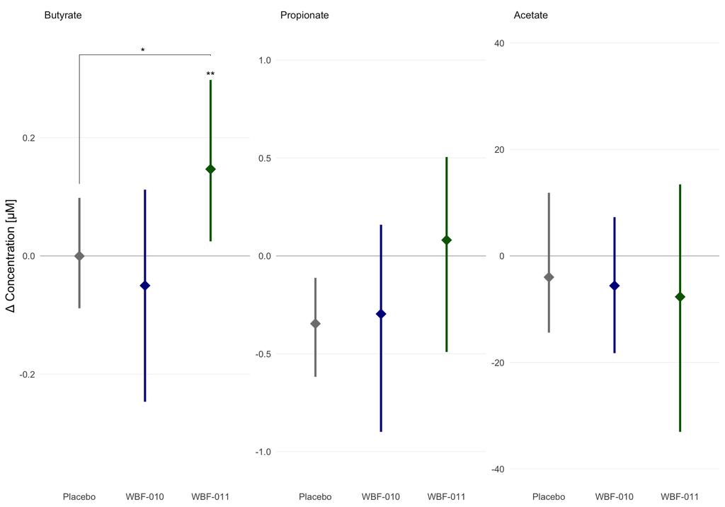

```r
# Summarize SCFA changes, clear butyrate increase.
padAnnotation = 0.2
tabFig2a <-
  tabWinGrpDelta %>% copy %>%
  .[, Treatment := studyArmPretty[Treatment]] %>%
  .[, scfa := factor(scfaNamePretty[BIOCHEMICAL], levels = rev(scfaNamePretty))]
# molecule-specific limits to enforce centering across panels despite free scale.
tabFig2aLims <-
  tabFig2a %>% copy %>%
  .[, .(
    y = (1 + padAnnotation) *
      max(abs(confIntHi), abs(confIntLo))
  ), by = .(Treatment, scfa)]
pFig2aConcentrationDelta <-
  tabFig2a %>%
  ggplot(aes(Treatment, estimate)) +
  facet_wrap(~scfa, scales = "free_y") +
  geom_hline(yintercept = 0, size = 0.1) +
  geom_blank(
    data = tabFig2aLims,
    mapping = aes(
      y = y,
      ymin = -y,
      ymax = y)
  ) +
  geom_pointrange(
    # alpha = 1.0,
    # size = 1.25,
    size = 1.,
    fatten = 4,
    shape = 23,
    stroke = 0,
    # fill = "black",
    mapping = aes(
      fill = Treatment,
      color = Treatment,
      # alpha = confIntLo > 0,
      # fill = confIntLo > 0,
      # color = confIntLo > 0,
      y = estimate,
      ymin = confIntLo,
      ymax = confIntHi)
  ) +
  scaleColorTreatmentManPretty +
  scaleFillTreatmentManPretty +
  # Bracket annotations
  ggpubr::geom_bracket(
    size = 0.2,
    bracket.nudge.y = -0.03,
    vjust = 0.7,
    hjust = 1,
    tip.length = c(0.3, 0.002),
    data = data.table(
      scfa = factor(
        x = "Butyrate",
        levels = scfaNamePretty %>% rev())
    ),
    xmin = "Placebo",
    xmax = "WBF-011",
    y.position = 0.37,
    label = "*") +
  geom_text(
    data = data.table(
      scfa = factor(
        x = "Butyrate",
        levels = scfaNamePretty %>% rev())
    ),
    x = "WBF-011",
    y = 0.305,
    label = "**"
  ) +
  ylab("\u0394 Concentration [\u03BCM]") +
  # ggtitle("\u0394 Concentration [\u03BCM]") +
  theme(
    plot.title = element_blank(),
    strip.background.x = element_rect(fill = NA, color = NA),
    strip.text.x = element_text(
      hjust = 0,
      size = 10,
      # margin = margin(0, 0, 1.4, 0, "pt"),
      face = "plain"
    ),
    panel.border = element_blank(),
    panel.grid.minor = element_blank(),
    panel.grid.major.x = element_blank(),
    panel.grid.major.y = element_line(size = 0.2),
    legend.position = "none",
    axis.text = element_text(size = 9),
    axis.ticks.x = element_blank(),
    axis.ticks.y = element_blank(),
    # axis.ticks.y = element_line(size = 0.2),
    axis.title.y = element_text(size = 12),
    axis.title.x = element_blank()
  )
pFig2aConcentrationDelta
```

# Fig 1B: Correlation bw fecal and circulating SCFA

## Join faecal and plasma SCFA

Show anti-intersections. Note: There are some ITT-only participants included in stool data. Loss of a few plasma-pairs (due to labeling, etc) on the plasma side.

```r
setdiff(tabFecalScfa$Subject, tabKey$Subject) %>% length()
```

```
## [1] 14
```

```r
setdiff(tabKey$Subject, tabFecalScfa$Subject) %>% length()
```

```
## [1] 9
```

Join

```r
tabFecalAndPlasma <- NULL
tabFecalAndPlasma <-
  (tabFecalScfa %>% copy %>%
     setnames("Concentration", "fecal_mM")) %>%
  .[(tabKey %>% copy %>% setnames("ConcMicroMolePerLiter", "plasma_uM")),
    on = c("Subject", "Event", "BIOCHEMICAL")]
```

Single trendline for each split. Let axes be free because acetate is canonically much higher concentration.

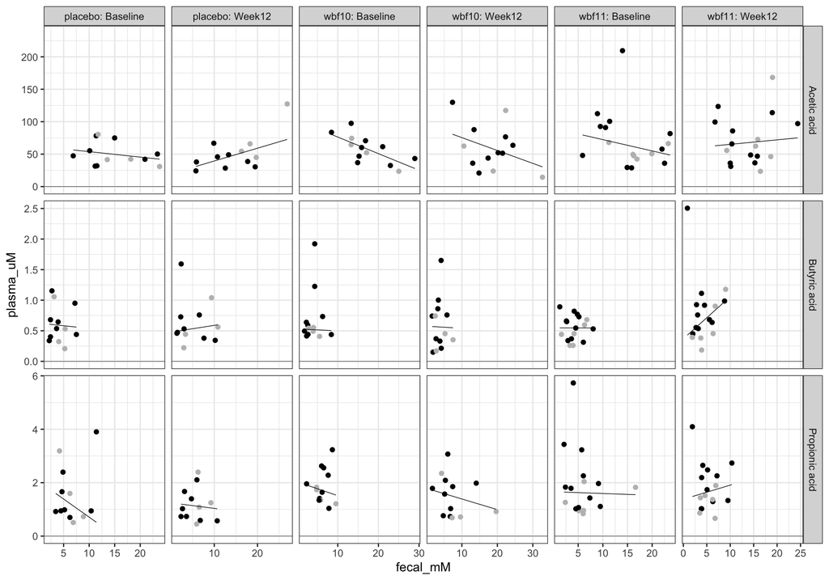

```r
tabFecalAndPlasma %>% copy %>%
  # join to add SFU status
  (tabSfu[, .(SulfonylureaDetected = SulfonylureaDetected[1]),
          by = "Subject"])[., on = "Subject"] %>%
  ggplot(aes(fecal_mM, plasma_uM)) +
  # facet_wrap(BIOCHEMICAL ~ Event, scales = "free") +
  facet_grid(BIOCHEMICAL ~ paste(Treatment, Event, sep = ": "),
             scales = "free") +
  # Enforce zero is in y-axis range
  geom_hline(
    size = 0.2,
    yintercept = 0.0,
    color = "black",
    alpha = 0.75) +
  geom_point(mapping = aes(color = SulfonylureaDetected), show.legend = FALSE) +
  scale_color_manual(values = c("TRUE" = "gray", "FALSE" = "black")) +
  geom_smooth(
    size = 0.25,
    # mapping = aes(color = treatment),
    se = FALSE,
    color = "black",
    method = robustbase::lmrob)
```

Is there a positive association there for butyrate?

Assess correlation, lm

```r
tabFecalPlasmaLmRes <- NULL
tabFecalPlasmaLmRes <-
  tabFecalAndPlasma %>%
  .[!is.na(fecal_mM)] %>%
  .[, .(
    lmrobOut = list(
      robustbase::lmrob(
        formula = plasma_uM ~ fecal_mM,
        data = .SD,
        na.action = na.exclude)
    ),
    spearmanCor = cor(fecal_mM, plasma_uM, method = "spearman"),
    spearmanCorPval =
      cor.test(fecal_mM, plasma_uM, method = "spearman")$p.value
  ), by = .(BIOCHEMICAL, Treatment, Event)]


extract_lmrob = function(lmrobOut){
  x <- NULL
  x <- lmrobOut %>% summary()
  data.table(
    slope = x$coefficients["fecal_mM", "Estimate"],
    slopeP = x$coefficients["fecal_mM", "Pr(>|t|)"],
    slopeSE = x$coefficients["fecal_mM", "Std. Error"]
  )
}

# (robust) lm results, butyrate at week-12 stands out
# As it does by eyeball in the chart
tabFecalPlasmaLmResVals <- NULL
tabFecalPlasmaLmResVals <-
  tabFecalPlasmaLmRes %>%
  .[, extract_lmrob(lmrobOut[[1]]),
    by = .(BIOCHEMICAL, Treatment, Event)] %>%
  setorder(BIOCHEMICAL, Treatment, Event)
tabFecalPlasmaLmResVals
```

```
##        BIOCHEMICAL Treatment    Event         slope      slopeP    slopeSE
##  1:    Acetic acid   placebo Baseline -0.8402549012 0.274620982 0.72697423
##  2:    Acetic acid   placebo   Week12  1.9739142306 0.609832097 3.74713497
##  3:    Acetic acid     wbf10 Baseline -2.5571864763 0.005520756 0.74328136
##  4:    Acetic acid     wbf10   Week12 -1.9857905506 0.189976385 1.42153492
##  5:    Acetic acid     wbf11 Baseline -1.7426816986 0.210984884 1.33362088
##  6:    Acetic acid     wbf11   Week12  0.6907099355 0.774590819 2.36873792
##  7:   Butyric acid   placebo Baseline -0.0088252712 0.869646289 0.05241488
##  8:   Butyric acid   placebo   Week12  0.0110925855 0.557468367 0.01827858
##  9:   Butyric acid     wbf10 Baseline -0.0032933994 0.858348154 0.01802512
## 10:   Butyric acid     wbf10   Week12 -0.0034248988 0.939349408 0.04399646
## 11:   Butyric acid     wbf11 Baseline -0.0002757615 0.991571939 0.02567463
## 12:   Butyric acid     wbf11   Week12  0.0688986807 0.003445188 0.01986931
## 13: Propionic acid   placebo Baseline -0.1357199320 0.201399548 0.09924294
## 14: Propionic acid   placebo   Week12 -0.0205958741 0.688867060 0.04996180
## 15: Propionic acid     wbf10 Baseline -0.0520299149 0.791743754 0.19230931
## 16: Propionic acid     wbf10   Week12 -0.0398583206 0.149206322 0.02570037
## 17: Propionic acid     wbf11 Baseline -0.0066772680 0.881389575 0.04399551
## 18: Propionic acid     wbf11   Week12  0.0528916263 0.836045858 0.25116646
```

```r
# Butyrate stands out here
tabFecalPlasmaLmResVals %>%
  .[(slope > 0 & slopeP < 0.1)] %>%
  knitr::kable(digits = 3)
```

| BIOCHEMICAL | Treatment | Event | slope | slopeP | slopeSE |
| --- | --- | --- | --- | --- | --- |
| Butyric acid | wbf11 | Week12 | 0.069 | 0.003 | 0.02 |

```r
# And correlation? Not as significant in assessment.
tabFecalPlasmaLmRes %>% copy %>%
  .[, lmrobOut := NULL] %>%
  setorder(BIOCHEMICAL, Treatment, Event) %>%
  knitr::kable(digits = 3)
```

| BIOCHEMICAL | Treatment | Event | spearmanCor | spearmanCorPval |
| --- | --- | --- | --- | --- |
| Acetic acid | placebo | Baseline | -0.231 | 0.471 |
| Acetic acid | placebo | Week12 | 0.378 | 0.227 |
| Acetic acid | wbf10 | Baseline | -0.714 | 0.008 |
| Acetic acid | wbf10 | Week12 | -0.154 | 0.617 |
| Acetic acid | wbf11 | Baseline | -0.353 | 0.165 |
| Acetic acid | wbf11 | Week12 | 0.098 | 0.708 |
| Butyric acid | placebo | Baseline | -0.091 | 0.783 |
| Butyric acid | placebo | Week12 | -0.035 | 0.921 |
| Butyric acid | wbf10 | Baseline | 0.066 | 0.835 |
| Butyric acid | wbf10 | Week12 | 0.137 | 0.656 |
| Butyric acid | wbf11 | Baseline | 0.071 | 0.787 |
| Butyric acid | wbf11 | Week12 | 0.218 | 0.399 |
| Propionic acid | placebo | Baseline | -0.175 | 0.588 |
| Propionic acid | placebo | Week12 | -0.084 | 0.800 |
| Propionic acid | wbf10 | Baseline | -0.044 | 0.892 |
| Propionic acid | wbf10 | Week12 | -0.313 | 0.297 |
| Propionic acid | wbf11 | Baseline | -0.137 | 0.599 |
| Propionic acid | wbf11 | Week12 | 0.088 | 0.737 |

Plot polish

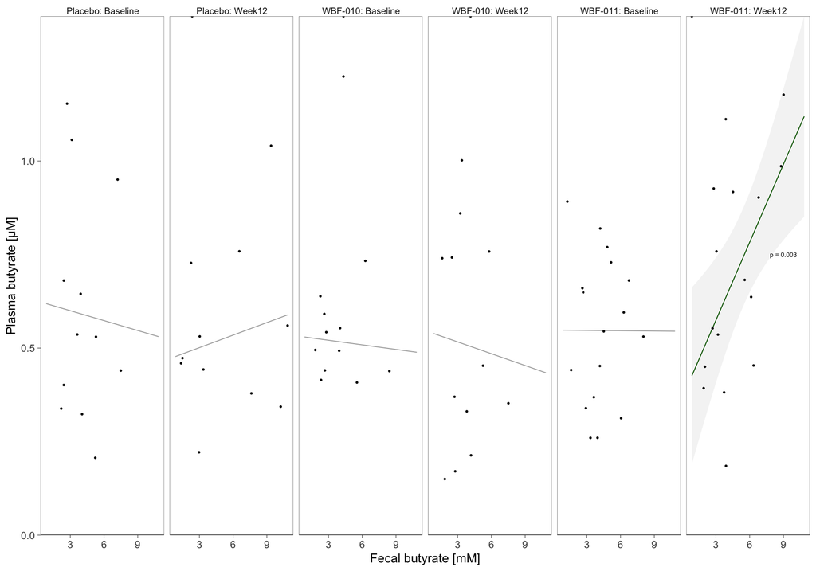

```r
pFecalPlasmaFit <- pFecalPlasmaFitSimple <- tabFecalAndPlasmaPlot <- NULL
tabFecalAndPlasmaPlot <-
  tabFecalAndPlasma %>% copy %>%
  .[(BIOCHEMICAL == "Butyric acid")] %>%
  .[, Treatment := factor(x = studyArmPretty[treatment],
                          levels = studyArmPretty)] %>%
  # Create new panel label from Treatment and Event
  .[, armTimeChar := paste(Treatment, Event, sep = ": ")] %>%
  setorder(Treatment, Event) %>%
  .[, armTime := factor(armTimeChar, levels = unique(armTimeChar))] %>%
  # For plotting purposes, set plasma values above 1.5 to Inf
  # Will have to explain these were left outside range as possible outliers
  # or at least skewing the rest of the pattern observable
  .[(plasma_uM > 1.5), plasma_uM := Inf]
pFecalPlasmaFitSimple <-
  tabFecalAndPlasmaPlot %>%
  ggplot(aes(fecal_mM, plasma_uM)) +
  # Omit extra bit of the scale
  scale_y_continuous(expand = c(0, 0)) +
  # facet_grid(treatment ~ Event, scales = "free") +
  facet_wrap(facets = vars(armTime), nrow = 1) +
  # scaleColorManualTreatment +
  # Enforce zero is in y-axis range
  geom_hline(
    size = 0.5,
    yintercept = 0.0,
    color = "black",
    alpha = 0.75) +
  # Dummy fit to emphasize the lack of pattern elsewhere
  geom_smooth(
    data = tabFecalAndPlasmaPlot,
    color = "darkgray",
    se = FALSE,
    size = 0.35,
    fullrange = TRUE,
    na.rm = TRUE,
    method = robustbase::lmrob,
  ) +
  # Just the non-trivial fit
  geom_smooth(
    data = tabFecalAndPlasmaPlot %>%
      .[(Treatment == "WBF-011")] %>%
      .[(Event == "Week12")],
    color = "darkgreen",
    fill = "gray90",
    size = 0.35,
    fullrange = TRUE,
    na.rm = TRUE,
    method = robustbase::lmrob,
  ) +
  geom_point(
    na.rm = TRUE,
    size = 0.4,
    color = "black",
    # mapping = aes(color = treatment),
    show.legend = FALSE) +
  ylab("Plasma butyrate [\u03BCM]") +
  xlab("Fecal butyrate [mM]") +
  theme(
    strip.background = element_rect(fill = NA, color = NA),
    strip.text.x = element_text(
      hjust = 0.5,
      size = 8,
      margin = margin(0, 0, 1.4, 1, "pt")
    ),
    panel.border = element_rect(size = 0.2),
    panel.spacing.y = unit(5, units = "pt"),
    panel.spacing.x = unit(5, units = "pt"),
    panel.grid.minor = element_blank(),
    panel.grid.major = element_blank(),
    legend.position = "none",
    axis.text = element_text(size = 9),
    axis.ticks = element_line(size = 0.2),
    axis.title = element_text(size = 11)
  )
# pFecalPlasmaFitSimple

# For main plot, add p-value annotation.
pFecalPlasmaFit <-
  pFecalPlasmaFitSimple +
  # Annotate slope and p-value
  geom_text(
    x = 9,
    y = 0.75,
    size = 2,
    mapping = aes(label = paste0("p = ", round(slopeP, digits = 3))),
    data =
      tabFecalPlasmaLmResVals %>% copy %>%
      .[, Treatment := factor(x = studyArmPretty[Treatment],
                              levels = studyArmPretty)] %>%
      .[, armTimeChar := paste(Treatment, Event, sep = ": ")] %>%
      .[, armTime := factor(armTimeChar, levels = unique(armTimeChar))] %>%
      .[(slope > 0 & slopeP < 0.1)]
  )
  # ggtitle("Association b/w fecal and circulating butyrate at Week-12?")
pFecalPlasmaFit
```

# Fig 1C: $\Delta$ HbA1c v. $\Delta$ Butyrate

Correlation changes in HbA1c and plasma SCFA

## Join

```r
tabGluCtlScfa <-
  tabPp %>%
  dcast.data.table(Subject ~ Event, value.var = c("A1C", "AUC_TOT_GLU")) %>%
  .[, deltaA1c := A1C_Week12 - A1C_Baseline] %>%
  .[, .(Subject, deltaA1c)] %>%
  # Join with scfa table
  .[tabScfaEventWide, on = "Subject"]
```

## Prepare param tables for Fig 1C

Show fit if SFU-detected are considered. $\Delta$A1c v. $\Delta$Butyrate

```r
# SFU+ subjects excluded
tabGluCtlScfa %>%
  .[(treatment == "wbf11")] %>%
  .[!(SulfonylureaDetected)] %>%
  .[(BIOCHEMICAL == "Butyric acid")] %>%
  robustbase::lmrob(formula = deltaA1c ~ Week12MinusBaseline,
                    data = .) %>%
  summary()
```

[output not shown]

```r
# SFU+ subjects excluded,
# high-leverage (high butyrate, < -2 deltaA1c) excluded
# (for the sake of argument)
tabGluCtlScfa %>%
  .[(treatment == "wbf11")] %>%
  .[!(SulfonylureaDetected)] %>%
  .[(BIOCHEMICAL == "Butyric acid")] %>%
  .[(deltaA1c > -2)] %>% # 0.008
  robustbase::lmrob(formula = deltaA1c ~ Week12MinusBaseline,
                    data = .) %>%
  summary()
```

```
##
## Call:
## robustbase::lmrob(formula = deltaA1c ~ Week12MinusBaseline, data = .)
##  \--> method = "MM"
## Residuals:
##       Min        1Q    Median        3Q       Max
## -1.391445 -0.171664  0.005407  0.060147  0.549477
##
## Coefficients:
##                     Estimate Std. Error t value Pr(>|t|)
## (Intercept)          -0.1697     0.1078  -1.574  0.15004
## Week12MinusBaseline  -0.8113     0.2395  -3.388  0.00803 **
## ---
## Signif. codes:  0 '***' 0.001 '**' 0.01 '*' 0.05 '.' 0.1 ' ' 1
##
## Robust residual standard error: 0.2032
## Multiple R-squared:  0.356,  Adjusted R-squared:  0.2844
## Convergence in 12 IRWLS iterations
##
## Robustness weights:
##  observation 6 is an outlier with |weight| = 0 ( < 0.0091);
##  3 weights are ~= 1. The remaining 7 ones are
##      1      2      3      5      8      9     10
## 0.9516 0.9879 0.7822 0.9953 0.9977 0.4447 0.7414
## Algorithmic parameters:
##        tuning.chi                bb        tuning.psi        refine.tol
##         1.548e+00         5.000e-01         4.685e+00         1.000e-07
##           rel.tol         scale.tol         solve.tol       eps.outlier
##         1.000e-07         1.000e-10         1.000e-07         9.091e-03
##             eps.x warn.limit.reject warn.limit.meanrw
##         1.819e-12         5.000e-01         5.000e-01
##      nResample         max.it       best.r.s       k.fast.s          k.max
##            500             50              2              1            200
##    maxit.scale      trace.lev            mts     compute.rd fast.s.large.n
##            200              0           1000              0           2000
##                   psi           subsampling                   cov
##            "bisquare"         "nonsingular"         ".vcov.avar1"
## compute.outlier.stats
##                  "SM"
## seed : int(0)
```

```r
# SFU param included rather than SFU+ excluded
tabGluCtlScfa %>%
  .[(treatment == "wbf11")] %>%
  .[(BIOCHEMICAL == "Butyric acid")] %>%
  robustbase::lmrob(formula = deltaA1c ~ SulfonylureaDetected + Week12MinusBaseline,
                    data = .) %>%
  summary()
```

```
##
## Call:
## robustbase::lmrob(formula = deltaA1c ~ SulfonylureaDetected + Week12MinusBaseline,
##     data = .)
##  \--> method = "MM"
## Residuals:
##      Min       1Q   Median       3Q      Max
## -1.47948 -0.29432  0.03533  0.18430  1.02257
##
## Coefficients:
##                          Estimate Std. Error t value Pr(>|t|)
## (Intercept)               -0.1506     0.2325  -0.648   0.5269
## SulfonylureaDetectedTRUE   0.7033     0.4824   1.458   0.1655
## Week12MinusBaseline       -1.1584     0.4449  -2.604   0.0199 *
## ---
## Signif. codes:  0 '***' 0.001 '**' 0.01 '*' 0.05 '.' 0.1 ' ' 1
##
## Robust residual standard error: 0.4234
##   (1 observation deleted due to missingness)
## Multiple R-squared:  0.6886, Adjusted R-squared:  0.6471
## Convergence in 18 IRWLS iterations
##
## Robustness weights:
##  2 weights are ~= 1. The remaining 16 ones are summarized as
##    Min. 1st Qu.  Median    Mean 3rd Qu.    Max.
##  0.1969  0.9049  0.9577  0.8730  0.9827  0.9990
## Algorithmic parameters:
##        tuning.chi                bb        tuning.psi        refine.tol
##         1.548e+00         5.000e-01         4.685e+00         1.000e-07
##           rel.tol         scale.tol         solve.tol       eps.outlier
##         1.000e-07         1.000e-10         1.000e-07         5.556e-03
##             eps.x warn.limit.reject warn.limit.meanrw
##         2.934e-12         5.000e-01         5.000e-01
##      nResample         max.it       best.r.s       k.fast.s          k.max
##            500             50              2              1            200
##    maxit.scale      trace.lev            mts     compute.rd fast.s.large.n
##            200              0           1000              0           2000
##                   psi           subsampling                   cov
##            "bisquare"         "nonsingular"         ".vcov.avar1"
## compute.outlier.stats
##                  "SM"
## seed : int(0)
```

The $\Delta$A1c v. $\Delta$Butyrate relationship is stronger than the SFU-naive and log-ratio fit would make it appear. Log-ratio is mostly useful in this context when multiple SCFA shown on the same plot (especially acetate dominates in both concentration baseline and change). Since we have already shown how butyrate stands out (especially in for negative-slope, when SFU is considered), and are showing just butyrate in the main figure, it makes sense to use the *natural* unit $\Delta$Butyrate [uM].

Correlation has a weak p-value (but WBF-011 most significant ranking).

```r
tabGluCtlScfa %>%
  # .[!(SulfonylureaDetected)] %>%
  .[(BIOCHEMICAL == "Butyric acid")] %>%
  .[!is.na(deltaA1c)] %>%
  .[, .(
    spearmanCor =
      cor(Week12MinusBaseline, deltaA1c, method = "spearman"),
    spearmanCorPval =
      cor.test(Week12MinusBaseline, deltaA1c, method = "spearman")$p.value
  ), by = .(BIOCHEMICAL, treatment, SulfonylureaDetected)] %>%
  setorder(treatment, SulfonylureaDetected) %>%
  knitr::kable(digits = 2)
```

| BIOCHEMICAL | treatment | SulfonylureaDetected | spearmanCor | spearmanCorPval |
| --- | --- | --- | --- | --- |
| Butyric acid | placebo | FALSE | 0.32 | 0.41 |
| Butyric acid | placebo | TRUE | 0.21 | 0.74 |
| Butyric acid | wbf10 | FALSE | -0.24 | 0.45 |
| Butyric acid | wbf10 | TRUE | 0.30 | 0.68 |
| Butyric acid | wbf11 | FALSE | -0.40 | 0.19 |
| Butyric acid | wbf11 | TRUE | 0.20 | 0.70 |

Define function to run lm function, extract results into table or return `NULL` if something went wrong

```r
run_lm_fun = function(testFormula, dt, lmfun = robustbase::lmrob){
  linmod <- dtOut <- linModSummary <- NULL
  trash <-
    try(silent = TRUE, expr = {
      linmod <-
        lmfun(
          formula = testFormula,
          data = dt)
    })
  if(!is.null(linmod)){
    trash <- try(silent = TRUE, expr = {
      dtOut <-
        summary(linmod) %>%
        coefficients() %>%
        as.data.frame() %>%
        set_colnames(c("paramEstimate", "stdErr", "tValue", "pFitParam")) %>%
        data.table(keep.rownames = "CoefficientName", skip_absent=TRUE) %>%
        .[, r2 := (summary(linmod)$r.squared)]
    })
  }
  return(dtOut)
}
```

The linear model slope parameter very negative, stands out dramatically from the others.

```r
tabGluCtlDeltaButyrate <- NULL
tabGluCtlDeltaButyrate <-
  tabGluCtlScfa %>%
  .[(BIOCHEMICAL == "Butyric acid")] %>%
  .[, .(
    lmA1c = list(
      run_lm_fun(
        testFormula =
          formula(deltaA1c ~ Week12MinusBaseline,
                  env = tabGluCtlScfa),
        dt = .SD,
        lmfun = robustbase::lmrob)
    )
  ), by = .(BIOCHEMICAL, treatment, SulfonylureaDetected)]
# Unfurl params
tabGluCtlDeltaButyrateParams <-
  tabGluCtlDeltaButyrate %>%
  .[!(lmA1c %>% sapply(is.null))] %>%
  .[, data.table(lmA1c[[1]]),
    by = .(BIOCHEMICAL, treatment, SulfonylureaDetected)] %>%
  setorder(-r2, pFitParam)
tabGluCtlDeltaButyrateParams %>%
  .[, .(BIOCHEMICAL, treatment, SulfonylureaDetected,
        CoefficientName, paramEstimate, pFitParam, r2)] %>%
  knitr::kable(digits = 3)
```

| BIOCHEMICAL | treatment | SulfonylureaDetected | CoefficientName | paramEstimate | pFitParam | r2 |
| --- | --- | --- | --- | --- | --- | --- |
| Butyric acid | wbf11 | FALSE | Week12MinusBaseline | -1.313 | 0.000 | 0.849 |
| Butyric acid | wbf11 | FALSE | (Intercept) | -0.072 | 0.474 | 0.849 |
| Butyric acid | wbf10 | TRUE | Week12MinusBaseline | 3.440 | 0.135 | 0.193 |
| Butyric acid | wbf10 | TRUE | (Intercept) | 0.407 | 0.529 | 0.193 |
| Butyric acid | placebo | FALSE | Week12MinusBaseline | 1.675 | 0.240 | 0.103 |
| Butyric acid | placebo | FALSE | (Intercept) | 0.119 | 0.756 | 0.103 |
| Butyric acid | wbf10 | FALSE | Week12MinusBaseline | -0.391 | 0.644 | 0.065 |
| Butyric acid | wbf10 | FALSE | (Intercept) | 0.162 | 0.683 | 0.065 |
| Butyric acid | placebo | TRUE | (Intercept) | 0.553 | 0.156 | 0.019 |
| Butyric acid | placebo | TRUE | Week12MinusBaseline | 1.005 | 0.673 | 0.019 |
| Butyric acid | wbf11 | TRUE | (Intercept) | 0.471 | 0.054 | 0.013 |
| Butyric acid | wbf11 | TRUE | Week12MinusBaseline | 0.278 | 0.852 | 0.013 |

```r
# Since it is drops below the digit threshold in the table,
# Show it explicitly
# (also shown above in the standard model summary):
tabGluCtlDeltaButyrateParams[1]$pFitParam
```

```
## [1] 2.977795e-07
```

Define plot.

```r
tabDeltaGluCtlButPlot <- pDeltaGluCtlBut <- NULL
tabDeltaGluCtlButPlot <-
  tabGluCtlScfa %>% copy %>%
  .[!is.na(deltaA1c)] %>%
  .[(BIOCHEMICAL == "Butyric acid")] %>%
  .[, Treatment := factor(x = studyArmPretty[treatment],
                          levels = studyArmPretty)]

# with WBF-011 high-leverage point excluded
tabDeltaGluCtlButHighLev <-
  tabDeltaGluCtlButPlot %>% copy %>%
  .[(deltaA1c < -2)]
tabDeltaGluCtlButPlot <-
  tabDeltaGluCtlButPlot %>%
  .[(deltaA1c > -2)]

# Define plot
pDeltaGluCtlBut <-
  tabDeltaGluCtlButPlot %>%
  ggplot(aes(Week12MinusBaseline, deltaA1c)) +
  facet_wrap(~Treatment, nrow = 1) +
  geom_hline(yintercept = 0.0, size = 0.1) +
  geom_vline(xintercept = 0.0, size = 0.1) +
  geom_smooth(
    data = tabDeltaGluCtlButPlot %>%
      .[(Treatment == "WBF-011" & !SulfonylureaDetected)],
    mapping = aes(group = SulfonylureaDetected),
    method = robustbase::lmrob,
    color = "darkgreen",
    fill = "gray90",
    size = 0.35,
    fullrange = TRUE,
    na.rm = TRUE,
    se = TRUE) +
  geom_text(
    hjust = 0,
    x = 0.75,
    y = -0.5,
    size = 2.5,
    # Format
    # parse = FALSE,
    # label = "p < 10^-6",
    # .[(deltaA1c > -2)] %>% # 0.008
    # See model summaries above,
    # this is with high-leverage point omitted.
    label = "p = 0.008",
    # mapping = aes(label = pFitParam),
    data = tabGluCtlDeltaButyrateParams %>% copy %>%
      .[(CoefficientName == "Week12MinusBaseline")] %>%
      .[(treatment == "wbf11")] %>%
      .[(SulfonylureaDetected == FALSE)] %>%
      .[, Treatment := factor(x = studyArmPretty[treatment],
                              levels = studyArmPretty)]
  ) +
  geom_point(
    mapping = aes(fill = SulfonylureaDetected),
    shape = 21,
    size = 2,
    stroke = 0
  ) +
  # Add back the high-leverage participant as open-circle
  geom_point(
    data = tabDeltaGluCtlButHighLev,
    shape = 21,
    size = 1.5,
    fill = "white",
    stroke = 0.5
  ) +
  scale_fill_manual(values = c("TRUE" = "gray", "FALSE" = "black")) +
  xlab("\u0394 Plasma butyrate [\u03BCM]") +
  ylab("\u0394 HbA1c") +
  theme(
    axis.title.y = element_text(size = 12, angle = 0, vjust = 0.5),
    axis.title.x = element_text(size = 10),
    panel.grid.major = element_blank(),
    panel.grid.minor = element_blank(),
    strip.text = element_text(size = 10),
    strip.background.x = element_rect(fill = NA, color = NA),
    strip.background.y = element_rect(fill = NA),
    legend.position = "none",
    axis.ticks = element_blank()
    )
# pDeltaGluCtlBut
```